DS 6030 | Fall 2024 | University of Virginia

# Homework #3: Penalized Regression

Author

Kiana Dane

Published

September 30, 2024

# Required R packages and Directories

```r
data_dir = 'https://mdporter.github.io/teaching/data/' # data directory
library(mlbench)
library(glmnet)
library(caret)
library(tidymodels)# for optional tidymodels solutions
library(tidyverse) # functions for data manipulation
```

# Problem 1: Optimal Tuning Parameters

In cross-validation, we discussed choosing the tuning parameter values that minimized the cross-validation error. Another approach, called the “one-standard error” rule [ISL pg 214, ESL pg 61], uses the values corresponding to the least complex model whose cv error is within one standard error of the best model. The goal of this assignment is to compare these two rules.

Use simulated data from `mlbench.friedman1(n, sd=2)` in the `mlbench` R package to fit *lasso models*. The tuning parameter $\lambda$ (corresponding to the penalty on the coefficient magnitude) is the one we will focus one. Generate training data, use k-fold cross-validation to get $\lambda_{\rm min}$ and $\lambda_{\rm 1SE}$, generate test data, make predictions for the test data, and compare performance of the two rules under a squared error loss using a hypothesis test.

Choose reasonable values for:

- Number of cv folds ($K$)
  - Note: you are free to use repeated CV, repeated hold-outs, or bootstrapping instead of plain cross-validation; just be sure to describe what do did so it will be easier to follow.
- Number of training and test observations
- Number of simulations
- If everyone uses different values, we will be able to see how the results change over the different settings.
- Don’t forget to make your results reproducible (e.g., set seed)

This pseudo code (using k-fold cv) will get you started:

```r
library(mlbench)
library(glmnet)

#-- Settings
n_train = 200        # number of training obs
n_test =  100       # number of test obs
K = 10              # number of CV folds
alpha = 1         # glmnet tuning alpha (1 = lasso, 0 = ridge)
M =              # number of simulations

#-- Data Generating Function
getData <- function(n) mlbench.friedman1(n) # data generating function

#-- Simulations
set.seed(123)

train_data <- getData(n=n_train)
train_x <- tibble(train_data$x)
train_y <- train_data$y

test_data <- getData(n=n_test)
test_x <- tibble(test_data$x)
test_y <- test_data$y

training_x <- as.matrix(train_x)
training_y <- train_y

lasso <- cv.glmnet(
  x = training_x, y = training_y,
  alpha = 1,
  nfolds = 10)

lambda_min <- lasso$lambda.min
lambda_1se <- lasso$lambda.1se

cat("lowest lambda (min):", lambda_min, "\n")
```

```
lowest lambda (min): 0.111
```

```r
cat("best lambda (1SE):", lambda_1se, "\n")
```

```
best lambda (1SE): 0.41
```

## a. Code for the simulation and performance results

**Solution**

```r
testing_x <- as.matrix(test_x)

lambda_min <- as.numeric(lambda_min)
lambda_1se <- as.numeric(lambda_1se)

pred_min <- predict(lasso, s = lambda_min, newx = testing_x)
pred_1se <- predict(lasso, s = lambda_1se, newx = testing_x)
```

```r
losses_min <- mean((test_y - pred_min)^2)

losses_1se <- mean((test_y - pred_1se)^2)

cat("loss for lambda.min:", losses_min, "\n")
```

```
loss for lambda.min: 5.63
```

```r
cat("loss for lambda.1se:", losses_1se, "\n")
```

```
loss for lambda.1se: 6.15
```

## b. Hypothesis test

Provide results and discussion of a hypothesis test comparing $\lambda_{\rm min}$ and $\lambda_{\rm 1SE}$.

**Solution**

```r
comparison_min_1se <- t.test((test_y - pred_min)^2, (test_y - pred_1se)^2)

comparison_min_1se
```

```
    Welch Two Sample t-test

data:  (test_y - pred_min)^2 and (test_y - pred_1se)^2
t = -0.4, df = 194, p-value = 0.7
alternative hypothesis: true difference in means is not equal to 0
95 percent confidence interval:
 -2.98  1.96
sample estimates:
mean of x mean of y
     5.63      6.15
```

While the t-statistic is very small, suggesting little difference between the error of the two models, the p-value from this t test is evidence that the difference in means of the two groups is not statistically significant. Also, a 95% CI includes zero. Therefore, there is no significant difference in the error loss between lambda(min) and lambda(1se).

# Problem 2 Prediction Contest: Real Estate Pricing

This problem uses the [realestate-train](https://mdporter.github.io/teaching/data//realestate-train.csv) and [realestate-test](https://mdporter.github.io/teaching/data//realestate-test.csv) (click on links for data).

The goal of this contest is to predict sale price (in thousands) (`price` column) using an *elastic net* model. Evaluation of the test data will be based on the root mean squared error ${\rm RMSE}= \sqrt{\frac{1}{m}\sum_i (y_i - \hat{y}_i)^2}$ for the $m$ test set observations.

## a. Load and pre-process data

Load the data and create necessary data structures for running *elastic net*.

- You are free to use any data transformation or feature engineering
- Note: there are some categorical predictors so at the least you will have to convert those to something numeric (e.g., one-hot or dummy coding).

**Solution**

```r
train_data <- read.csv("realestate-train.csv")
test_data <- read.csv("realestate-test.csv")

X = glmnet::makeX(select(train_data, -price), test_data)
X.train = X$x
X.test = X$xtest
Y.train = train_data$price
```

## b. Fit elastic net model

Use an *elastic net* model to predict the `price` of the test data.

- You are free to use any data transformation or feature engineering
- You are free to use any tuning parameters
- Report the $\alpha$ and $\lambda$ parameters you used to make your final predictions.
- Describe how you choose those tuning parameters

**Solution**

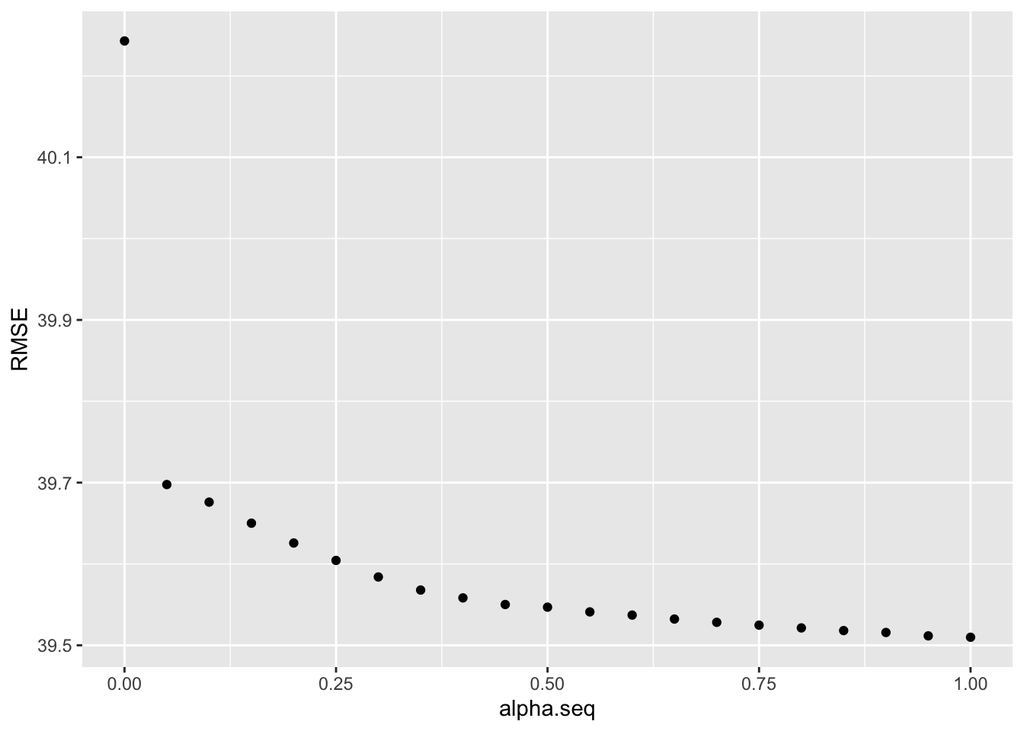

```r
set.seed(9903)
K=10
folds = rep(1:K, length=nrow(X.train)) %>% sample()

mse_estimate <- function(alpha, folds) {
  mse = cv.glmnet(X.train, Y.train, foldid=folds, alpha=alpha)$cvm %>% min()
  sqrt(mse)
}

alpha.seq = seq(0,1, by=0.05)

set.seed(1)
RMSE = purrr::map_dbl(alpha.seq, \(a) mse_estimate(a, folds=folds))

qplot(alpha.seq, RMSE)
```

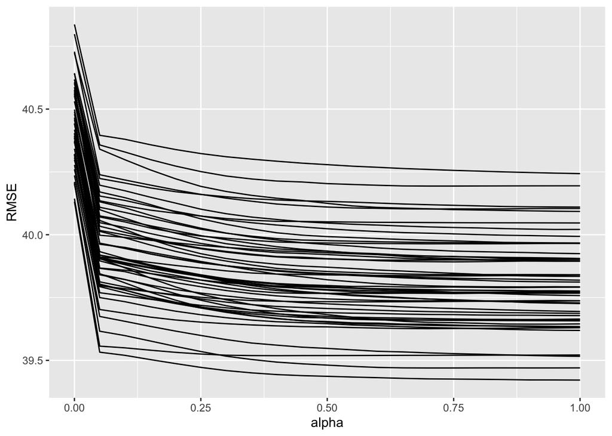

```r
set.seed(2)
RMSE2 = tibble()
for (i in 1:50) {
  folds_new = sample(folds)
  rmse = tibble(
    iter = i,
    alpha = alpha.seq,
    RMSE = purrr::map_dbl(alpha.seq, \(a) mse_estimate(a, folds=folds_new))
  )
  RMSE2 = bind_rows(RMSE2, rmse)
}

RMSE2 %>%
  ggplot(aes(alpha, RMSE, group=iter)) + geom_line()
```

## c. Submit predictions

Submit a .csv file (ensure comma separated format) named `lastname_firstname.csv` that includes your predictions in a column named *yhat*. We will use automated evaluation, so the format must be exact.

- You will receive credit for a proper submission; the top five scores will receive 2 bonus points.

**Solution**

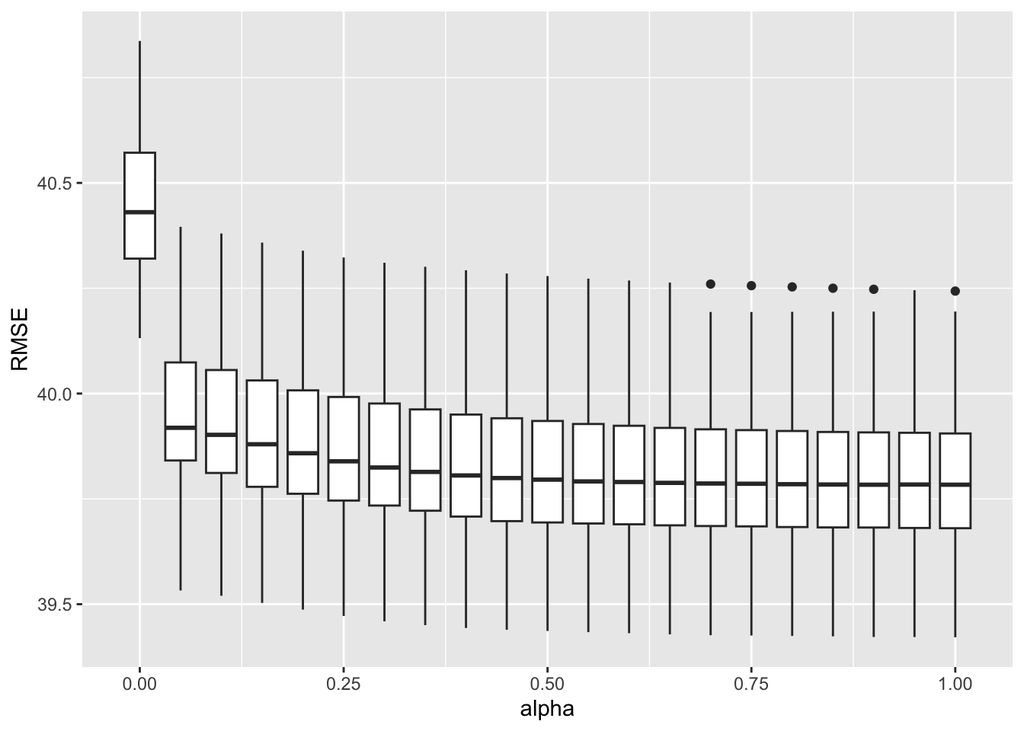

```r
RMSE2 %>%
  ggplot(aes(alpha, RMSE, group = alpha)) + geom_boxplot()
```

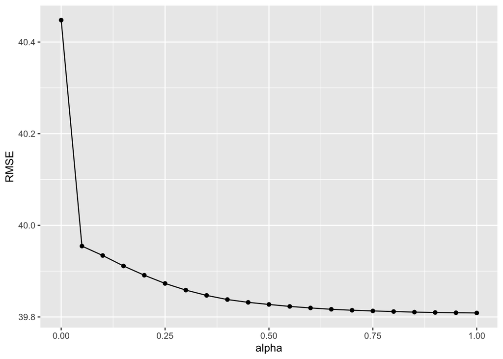

```r
RMSE.mu = RMSE2 %>%
  group_by(alpha) %>% summarize (RMSE=mean(RMSE), RMSE.median = median(RMSE))

RMSE.mu %>%
  group_by(alpha) %>% summarize (RMSE=mean(RMSE)) %>%
  ggplot(aes(alpha, RMSE)) + geom_point() + geom_line()
```

```r
RMSE.mu %>% arrange(RMSE)
```

```
# A tibble: 21 × 3
  alpha  RMSE RMSE.median
  <dbl> <dbl>       <dbl>
1  1     39.8        39.8
2  0.95  39.8        39.8
3  0.9   39.8        39.8
4  0.85  39.8        39.8
5  0.8   39.8        39.8
6  0.75  39.8        39.8
# ℹ 15 more rows
```

```r
(alpha.hat = RMSE.mu %>% slice_min(RMSE) %>% pull(alpha))
```

```
[1] 1
```

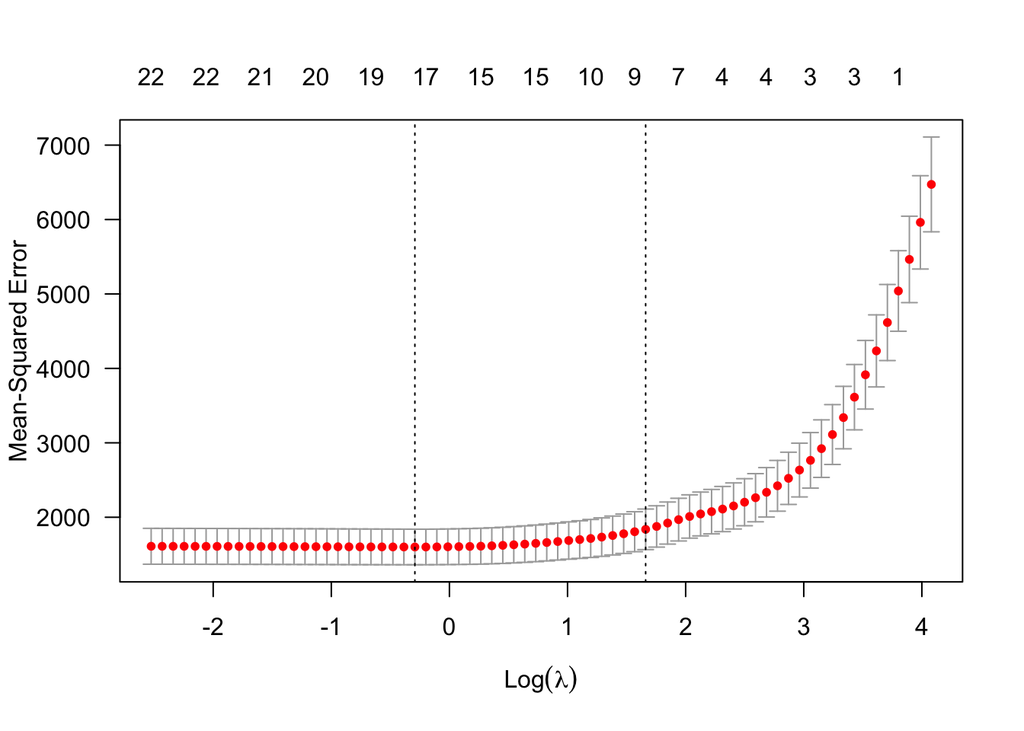

```r
set.seed(3)
K=10
cv.fit = cv.glmnet(X.train, Y.train, nfolds=K, alpha=alpha.hat)
plot(cv.fit, las=1)
```

```r
(lambda.hat = cv.fit$lambda.min)
```

```
[1] 0.747
```

```r
lambda.hat
```

```
[1] 0.747
```

## d. Report anticpated performance

Report the anticipated performance of your method in terms of RMSE. We will see how close your performance assessment matches the actual value.

**Solution**

```r
ind = which.min(cv.fit$cvm)
sqrt(cv.fit$cvm[ind])
```

```
[1] 40
```

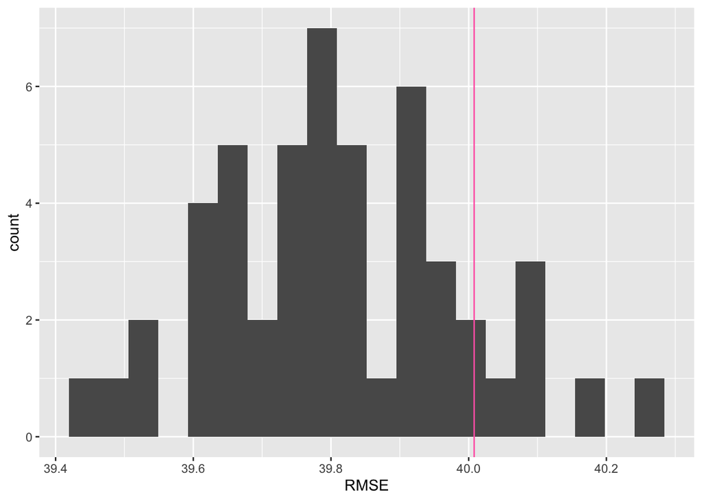

```r
performance = RMSE2 %>% filter(alpha == alpha.hat)

performance %>%
  ggplot(aes(RMSE)) + geom_histogram(bins=20) +
  geom_vline(xintercept = sqrt(cv.fit$cvm[ind]), color = "hotpink")
```

```r
(mean(performance$RMSE))
```

```
[1] 39.8
```

```r
(qt(0.975, df=nrow(performance)-1)*sd(performance$RMSE)/sqrt(n_distinct(RMSE2$iter)))
```

```
[1] 0.0514
```

```r
fit = glmnet(X.train, Y.train, alpha=alpha.hat)

yhat = predict(fit, newx = X.test, s=lambda.hat)[,1]

tibble(yhat) %>% write_csv("dane_kiana.csv")
```

```r
#data.test = read_csv("realestate-test.csv")
#yardstick::rmse_vec(truth=data.test$price, yhat)
```